# Part I - Loan Dataset analysis and exploration

## by (Dakhouche Salah Eddine)

## Introduction

Int this project we will explore the loan dataset to find any relation between the caractérisrique of the loan and the percentage funded and the number on investors that invst on the loans

## Preliminary Wrangling

```python
# import all packages and set plots to be embedded inline
import numpy as np
import pandas as pd
import matplotlib.pyplot as plt
import seaborn as sb

%matplotlib inline
```

### Load the dataset

```python
pd.set_option('display.max_columns', None)
```

```python
df = pd.read_csv('Loan.csv')
```

```python
df.shape
```

```
(113937, 81)
```

```python
# We are gonna take the columns needed for this ptoject after reading the documentation of the data set
loan=df[['ListingKey','Term','LoanStatus','LoanOriginalAmount','EstimatedReturn','ProsperScore','DelinquenciesLast7Years','DebtToIncomeRatio','IncomeRange','IncomeVerifiable','PercentFunded','Investors']]
```

**I have stored the new data set on a csv file called loans.csv just to free memory**

```python
loan=pd.read_csv('loans.csv')
```

```python
loan.drop('Unnamed: 0', axis=1,inplace=True)
```

```python
print(loan.shape)
print(loan.info())
print(loan.describe())
```

```
(113937, 12)
<class 'pandas.core.frame.DataFrame'>
RangeIndex: 113937 entries, 0 to 113936
Data columns (total 12 columns):
 #   Column                   Non-Null Count   Dtype
---  ------                   --------------   -----
 0   ListingKey               113937 non-null  object
 1   Term                     113937 non-null  int64
 2   LoanStatus               113937 non-null  object
 3   LoanOriginalAmount       113937 non-null  int64
 4   EstimatedReturn          84853 non-null   float64
 5   ProsperScore             84853 non-null   float64
 6   DelinquenciesLast7Years  112947 non-null  float64
 7   DebtToIncomeRatio        105383 non-null  float64
 8   IncomeRange              113937 non-null  object
 9   IncomeVerifiable         113937 non-null  bool
 10  PercentFunded            113937 non-null  float64
 11  Investors                113937 non-null  int64
dtypes: bool(1), float64(5), int64(3), object(3)
memory usage: 9.7+ MB
None
                Term  LoanOriginalAmount  EstimatedReturn  ProsperScore  \
count  113937.000000        113937.00000     84853.000000  84853.000000
mean       40.830248          8337.01385         0.096068      5.950067
std        10.436212          6245.80058         0.030403      2.376501
min        12.000000          1000.00000        -0.182700      1.000000
25%        36.000000          4000.00000         0.074080      4.000000
50%        36.000000          6500.00000         0.091700      6.000000
75%        36.000000         12000.00000         0.116600      8.000000
max        60.000000         35000.00000         0.283700     11.000000

       DelinquenciesLast7Years  DebtToIncomeRatio  PercentFunded  \
count            112947.000000      105383.000000  113937.000000
mean                  4.154984           0.275947       0.998584
std                  10.160216           0.551759       0.017919
min                   0.000000           0.000000       0.700000
25%                   0.000000           0.140000       1.000000
50%                   0.000000           0.220000       1.000000
75%                   3.000000           0.320000       1.000000
max                  99.000000          10.010000       1.012500

           Investors
count  113937.000000
mean       80.475228
std       103.239020
min         1.000000
25%         2.000000
50%        44.000000
75%       115.000000
max      1189.000000
```

```python
loan.head()
```

|  | ListingKey | Term | LoanStatus | LoanOriginalAmount | EstimatedReturn | ProsperScore | DelinquenciesLast7Years | DebtToIncomeRatio | IncomeRange | IncomeVerifiable | PercentFunded | Investors |
| --- | --- | --- | --- | --- | --- | --- | --- | --- | --- | --- | --- | --- |
| 0 | 1021339766868145413AB3B | 36 | Completed | 9425 | NaN | NaN | 4.0 | 0.17 | $25,000-49,999 | True | 1.0 | 258 |
| 1 | 10273602499503308B223C1 | 36 | Current | 10000 | 0.05470 | 7.0 | 0.0 | 0.18 | $50,000-74,999 | True | 1.0 | 1 |
| 2 | 0EE9337825851032864889A | 36 | Completed | 3001 | NaN | NaN | 0.0 | 0.06 | Not displayed | True | 1.0 | 41 |
| 3 | 0EF5356002482715299901A | 36 | Current | 10000 | 0.06000 | 9.0 | 14.0 | 0.15 | $25,000-49,999 | True | 1.0 | 158 |
| 4 | 0F023589499656230C5E3E2 | 36 | Current | 15000 | 0.09066 | 4.0 | 0.0 | 0.26 | $100,000+ | True | 1.0 | 20 |

### What is the main feature of interest in this dataset?

I’m interested to find out what can influence the percentage of funding the loan got and the number of investors invested on the loan

### What features in the dataset do you think will help support your investigation into your feature(s) of interest?

I'm expecting that the **DelinquenciesLast7Years**, **ProsperScore**, and **EstimatedReturn** will have the most impact on the percentage of funding and the number of investors

```python
colorM=(120/255, 149/255, 178/255)
rng = ['Not employed','$0', '$1-24,999', '$25,000-49,999', '$50,000-74,999','$75,000-99,999','$100,000+','Not displayed']
incrang = pd.api.types.CategoricalDtype(ordered=True, categories=rng)
loan['IncomeRange']=loan['IncomeRange'].astype(incrang)
```

## Univariate Exploration

For this part we will appreciate the distribution of each variable, and find explanations for unusual distributions

### 1. The distribution of the prosper risk of loans

the ProsperScore is an ordinal data between 1 and 10 that represent the risk of the prosper, 10 been the lowest risk

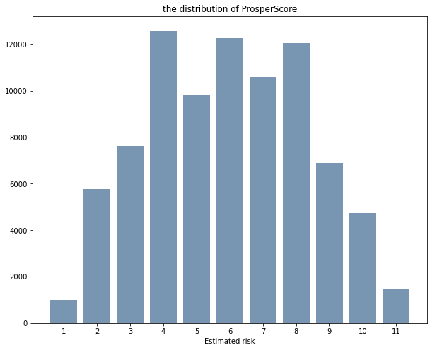

```python
plt.figure(figsize=(10,8))
plt.colorbar=(colorM)
x=loan['ProsperScore'].value_counts().sort_index().index
y=loan['ProsperScore'].value_counts().sort_index()
plt.bar(x,y ,color=colorM)
plt.xticks(x, ('1', '2', '3', '4','5','6','7','8','9','10','11'))
plt.xlabel('Estimated risk')
plt.title('the distribution of ProsperScore')
plt.show()
```

As shown by this visualization the majority of loans has low to moderate/hight risk, the majority of loans have between 9 and 3, and the distribution seems normaly distributed. we have a grade that needed to be removed because we don't know the significance of it, it is 11 and more of a 1000 loans have 11 as score of risk.

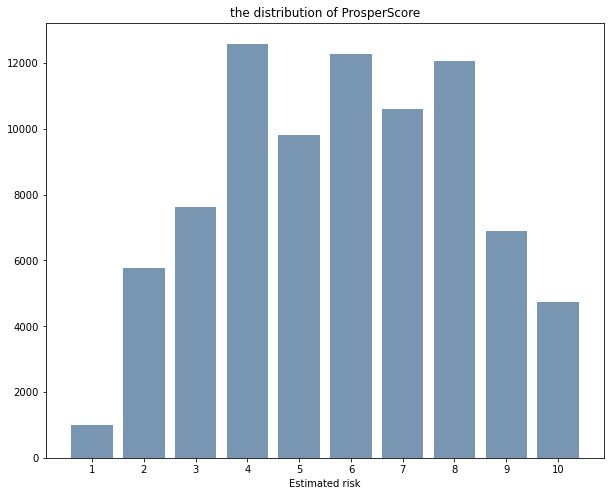

```python
loan = loan.loc[loan['ProsperScore']<11]
plt.figure(figsize=(10,8))
plt.colorbar=(colorM)
x=loan['ProsperScore'].value_counts().sort_index().index
y=loan['ProsperScore'].value_counts().sort_index()
plt.bar(x,y ,color=colorM)
plt.xticks(x, ('1', '2', '3', '4','5','6','7','8','9','10'))
plt.xlabel('Estimated risk')
plt.title('the distribution of ProsperScore')
plt.show()
```

### 2. What is the distribution of the term of loans on this data set?

this variable is essential in order to understand the structure of the dataset, and can explain the distribution of other variables

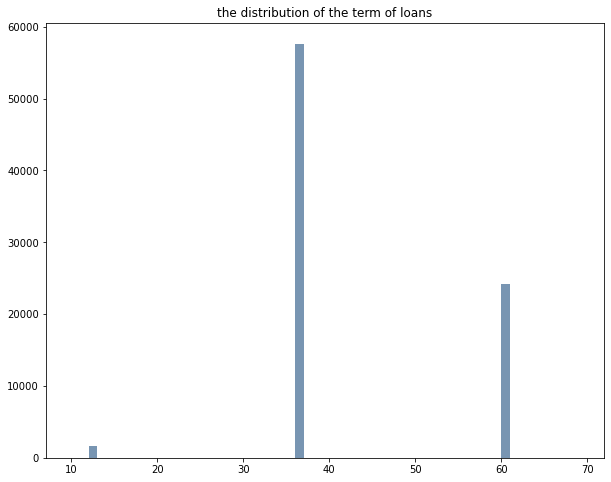

```python
rang = np.arange(10,70,1)
plt.figure(figsize=(10,8))
plt.hist(data=loan, x='Term',bins=rang,color=colorM)
plt.title('the distribution of the term of loans')
plt.show()
```

```python
loan['Term'].value_counts()
```

```
36    57646
60    24138
12     1613
Name: Term, dtype: int64
```

**the visualization shows that there is 3 term types in this data set 12, 36, and 60 months most of the loans have 36 month terms that mean mid-term loans are the most frequente**

### 3. What is the distribution of original amount of the loan?

Logically this variable can have an impact on the number of investors and the precentage of funding.

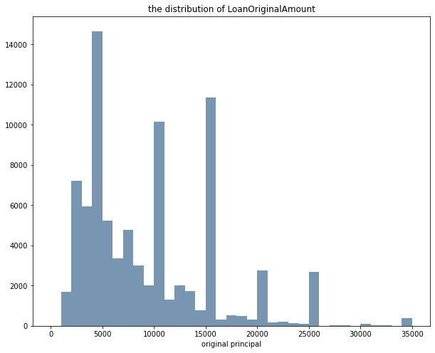

```python
rang = np.arange(0,35000+1000,1000)
plt.figure(figsize=(10,8))
plt.hist(data=loan, x='LoanOriginalAmount',bins=rang,color=colorM)
plt.xlabel("original principal")
plt.title('the distribution of LoanOriginalAmount')
plt.show()
```

We can see that the majority of loans are beween 1000 and 15000 dollars with the highest amount of loans between 4000 and 5000 dollars. the visualization shows that low debts are more frequente that higher ones as expected if we see the distribution of the term of loans

### 4. What is the distribution of loan status?

```python
srt=loan['LoanStatus'].value_counts().sort_values(ascending=True)
```

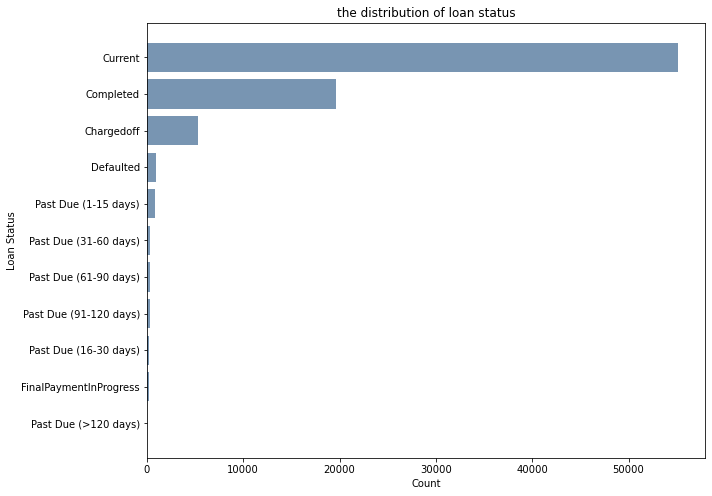

```python
plt.figure(figsize=(10,8))
plt.colorbar=(colorM)
plt.barh(srt.index, srt,color=colorM)
plt.xlabel('Count')
plt.ylabel('Loan Status')
plt.title('the distribution of loan status')
plt.show()
```

### 5. What is the distribution of estimated return?

The estimated return is an interesting variable for investors, and normally if the estimated return is hight the more investors are interested.

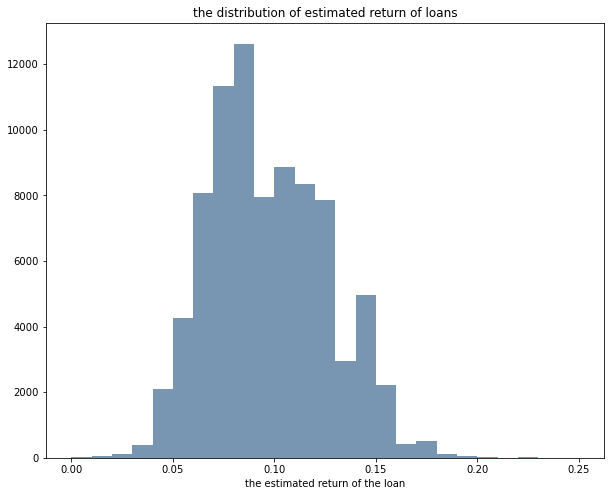

```python
rang = np.arange(0,0.25+0.01,0.01)
plt.figure(figsize=(10,8))
plt.hist(data=loan, x='EstimatedReturn',bins=rang,color=colorM)
plt.xlabel("the estimated return of the loan")
plt.title('the distribution of estimated return of loans')
plt.show()
```

We see that the majority of the estimated return of the loans fall between 7% to 13%, we can consider that is a normal ditribution

the delinquencies can have a big impact on the decision of the investors this is why we are gonna first appreciate the distribution of it.

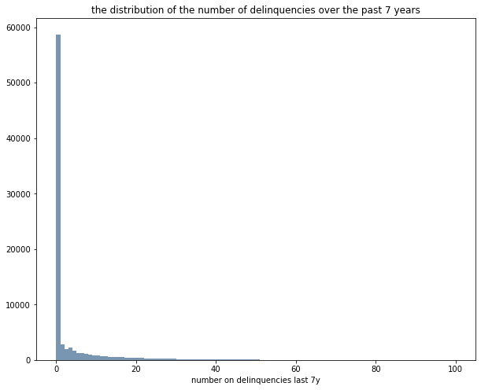

```python
rang = np.arange(0,100+1,1)
plt.figure(figsize=(10,8))
plt.hist(data=loan, x='DelinquenciesLast7Years',bins=rang,color=colorM)
plt.xlabel("number on delinquencies last 7y")
plt.title('the distribution of the number of delinquencies over the past 7 years')
plt.show()
```

```python
loan['DelinquenciesLast7Years'].value_counts().index
```

```
Float64Index([ 0.0,  1.0,  3.0,  2.0,  4.0,  5.0,  6.0,  7.0,  8.0,  9.0, 10.0,
              11.0, 12.0, 13.0, 15.0, 14.0, 16.0, 17.0, 18.0, 20.0, 19.0, 21.0,
              23.0, 24.0, 22.0, 25.0, 26.0, 27.0, 28.0, 29.0, 30.0, 32.0, 31.0,
              33.0, 35.0, 34.0, 37.0, 38.0, 39.0, 36.0, 42.0, 44.0, 41.0, 40.0,
              46.0, 43.0, 48.0, 49.0, 45.0, 47.0, 50.0, 99.0, 51.0, 52.0, 56.0,
              53.0, 60.0, 55.0, 61.0, 65.0, 54.0, 62.0, 63.0, 59.0, 64.0, 58.0,
              57.0, 68.0, 66.0, 69.0, 67.0, 75.0, 71.0, 73.0, 77.0, 70.0, 72.0,
              92.0, 90.0, 78.0, 82.0, 88.0, 79.0, 83.0, 95.0, 74.0, 80.0, 86.0,
              89.0, 87.0, 81.0, 84.0, 94.0, 76.0, 91.0, 98.0, 96.0, 93.0,
              97.0],
             dtype='float64')
```

The majority of borrowers have 0 delinquencies over the last 7 years and the frequency of borrowers decrease with increase of number of delinquencies. To have a better view we can perform o log transformation.

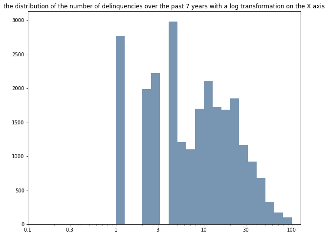

```python
bins = 10 ** np.arange(0, 2+0.1, 0.1)

# ticks needed for the viz
ticks = [0.1, 0.3, 1, 3, 10, 30, 100]
labels = ['{}'.format(v) for v in ticks]
plt.figure(figsize=(10,8))
# hist
plt.hist(data=loan, x='DelinquenciesLast7Years', bins=bins,color=colorM);

# log transformation
plt.xscale('log')
plt.title('the distribution of the number of delinquencies over the past 7 years with a log transformation on the X axis')
# Appliquer les x-ticks
plt.xticks(ticks, labels);
```

the visualization shows that there is 4 another peaks in addition to the first one 0, on the 1, 3, 5 and between 10 and 30. But overrall we have the same decrease as the previous graph.

## 7. We are gonna appreciate the distribution of the debt to income ratio of the borrowers

The Debt to income ration is a variable that can tell the ability of a borrower to pay back his debt, that means that the higher the ration the probability of payement delinquencies, this can to impat the percentage funded and the number of investors.

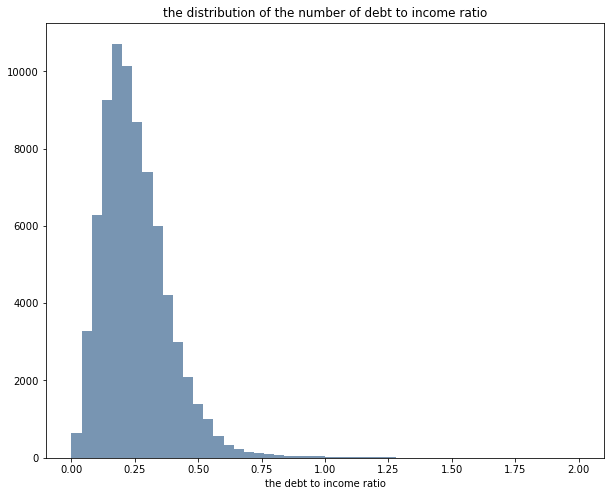

```python
rang = np.arange(0,2+0.04,0.04)
plt.figure(figsize=(10,8))
plt.hist(data=loan, x='DebtToIncomeRatio',bins=rang,color=colorM)
plt.xlabel("the debt to income ratio")
plt.title('the distribution of the number of debt to income ratio')
plt.show()
```

We see that we ahve a long right taled histogram, most of borrower have between 8% and 40% debt to income ratio with a mode of 18%-20%.

## 8. The distibution of income rang

the variable is categorical and ordinaln representing the income rage of the borrowers, normaly the higher the income the safer are the investors.

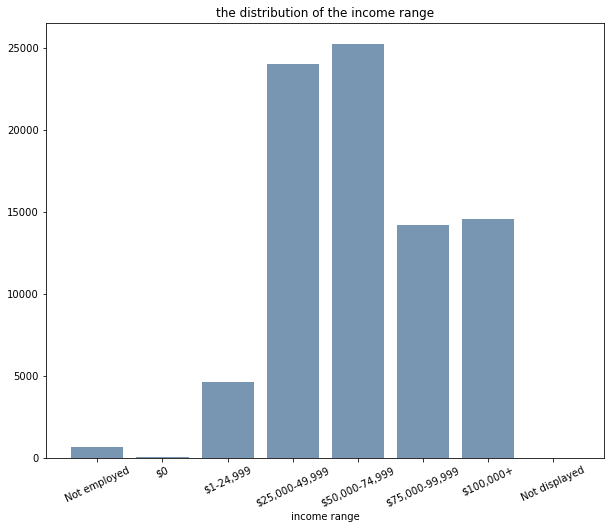

```python
x=loan['IncomeRange'].value_counts().sort_index().index
y=loan['IncomeRange'].value_counts().sort_index()
plt.figure(figsize=(10,8))
plt.colorbar=(colorM)
plt.bar(x,y ,color=colorM)
plt.xticks(rotation=25)
plt.xlabel('income range')
plt.title('the distribution of the income range')
plt.show()
```

## 9. how the percentFunded variable is distributed?

this variable has the most importance in our analysis, we will see how this variable change with the change of the other variables to answer the question on what are the things that impact the funding and we can predict the if a listed loan can will be fully funded or partialy

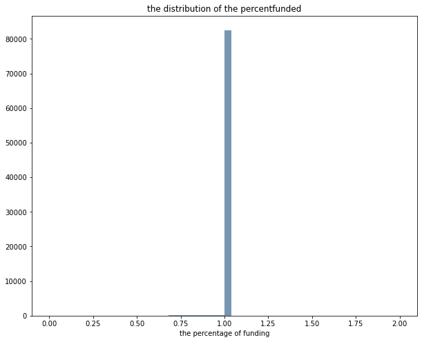

```python
rang = np.arange(0,2+0.04,0.04)
plt.figure(figsize=(10,8))
plt.hist(data=loan, x='PercentFunded',bins=rang,color=colorM)
plt.xlabel("the percentage of funding")
plt.title('the distribution of the percentfunded')
plt.show()
```

```python
loan['PercentFunded'].value_counts()
```

```
1.0000    82534
0.9998        5
0.7000        4
0.8087        4
0.7803        3
          ...
0.7700        1
0.8972        1
0.8237        1
0.9113        1
0.7067        1
Name: PercentFunded, Length: 714, dtype: int64
```

```python
len(loan['PercentFunded'])-loan['PercentFunded'].value_counts()[1]
```

```
863
```

```python
#creatiing a data set with all loans not fully funded and 10 samples of fully funded
sample1 = loan.loc[loan['PercentFunded']<1]
sample2 = loan.loc[loan['PercentFunded']==1].sample(200)
merged_sample=[sample1,sample2]
merged_sample=pd.concat(merged_sample)
```

```python
#this line of code is not meant to be executed, I used it to store the sample created above, and to have the same
# result and visualization in this project each time
merged_sample.to_csv('sample.csv')
```

```python
merged_sample = pd.read_csv('sample.csv')
```

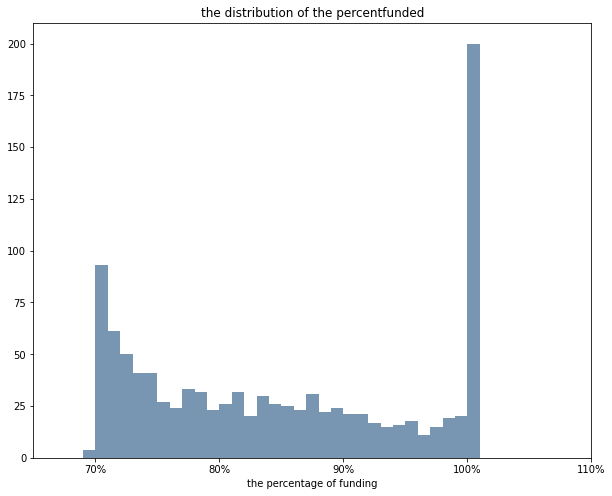

```python
rang = np.arange(0,2+0.01,0.01)
plt.figure(figsize=(10,8))
plt.hist(data=merged_sample, x='PercentFunded',bins=rang,color=colorM)
plt.xticks([0.7,0.8,0.9,1.0,1.1],["70%","80%","90%","100%","110%"])
plt.xlabel("the percentage of funding")
plt.xlim([0.65,1.1])
plt.title('the distribution of the percentfunded')
plt.show()
```

we found that the distribution the PercentageFunded of the new data set has a peak in 70% but and start to fall after, we have another peak on 100% mainly because of our sample just to repreduce the same distibution. this dataset can be used to better answer the question about what are the variables that impact the percentage Funded.

## 10. What is the distribution of investors on each loan

```python
loan['Investors'].value_counts()
```

```
1      26609
2       1199
3        868
4        695
8        613
       ...
679        1
586        1
610        1
774        1
618        1
Name: Investors, Length: 677, dtype: int64
```

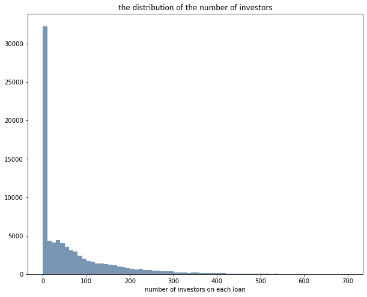

```python
rang = np.arange(0,700+10,10)
plt.figure(figsize=(10,8))
plt.hist(data=loan, x='Investors',bins=rang,color=colorM)
plt.xlabel("number of investors on each loan")
plt.title('the distribution of the number of investors')
plt.show()
```

We can see that we have a peak on loans that have 1 investors, this can be explained by the low amount of the loan shown on the graph of the distribution of LoanOriginalAmount variable. **we are gonna take a look on the distribution on the sample dataset**

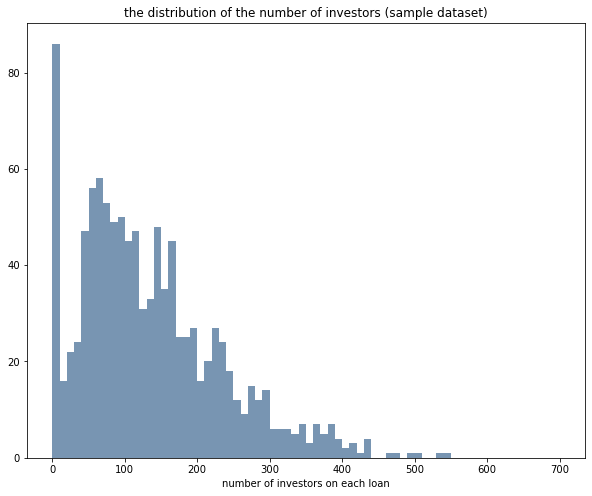

```python
rang = np.arange(0,700+10,10)
plt.figure(figsize=(10,8))
plt.hist(data=merged_sample, x='Investors',bins=rang,color=colorM)
plt.xlabel("number of investors on each loan")
plt.title('the distribution of the number of investors (sample dataset)')
plt.show()
```

we have a long taled graph with a seconde peak on the 60-70 investors, the next step we are gonna do a log transformation

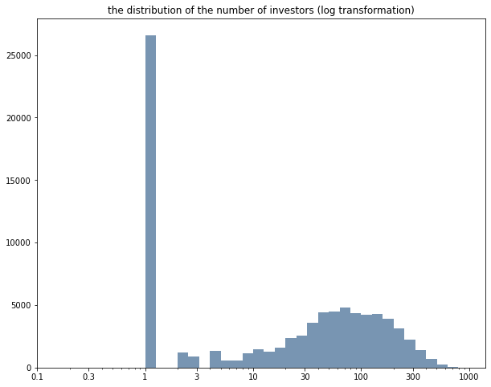

```python
bins = 10 ** np.arange(0, 3+0.1, 0.1)

# ticks needed for the viz
ticks = [0.1, 0.3, 1, 3, 10, 30, 100, 300, 1000]
labels = ['{}'.format(v) for v in ticks]
plt.figure(figsize=(10,8))
# hist
plt.hist(data=loan, x='Investors', bins=bins,color=colorM);

# log transformation
plt.xscale('log')

plt.title('the distribution of the number of investors (log transformation)')
# Appliquer les x-ticks
plt.xticks(ticks, labels);
```

after the log transformation we have a better view of the distribution of the variable, we have two peaks, the first is on the 1 investors and the second is between 30 and 250 investors. we can do the same opration done for the previous variable and take sample from loans that have 1 investors, just to have an evenly distributed data set

### Discuss the distribution(s) of your variable(s) of interest. Were there any unusual points? Did you need to perform any transformations?

I found the percentFunded distribution has a big gab between 100% and the other percentages due to the fact that the majority of loans are fully funded, I merged 200 samples of fully funded loans with the partialy funded ones to make ana analysis of what impacts the percntage of fundings. seconde thing on the number of investors, I performed a log transformation on the number on investors on each loan and found that theri is 2 peaks on the distribution, the same transformation is performed on the number of Delinquencies in the past 7 years and found that there is 4 more peaks in the distribution.

### Of the features you investigated, were there any unusual distributions? Did you perform any operations on the data to tidy, adjust, or change the form of the data? If so, why did you do this?

when i was exploring the data set I found that loans have 3 types of terms 12, 36 and 60, and there is some loans that have a rate of 11 and normaly the grades needs to be between 1 and 10.

## Bivariate Exploration

> We are gonna start by looking at the correlations between variable

```python
num = ['LoanOriginalAmount','EstimatedReturn','DelinquenciesLast7Years','DebtToIncomeRatio','PercentFunded','Investors']
cat = ['Term','LoanStatus','ProsperScore','IncomeRange','IncomeVerifiable']
```

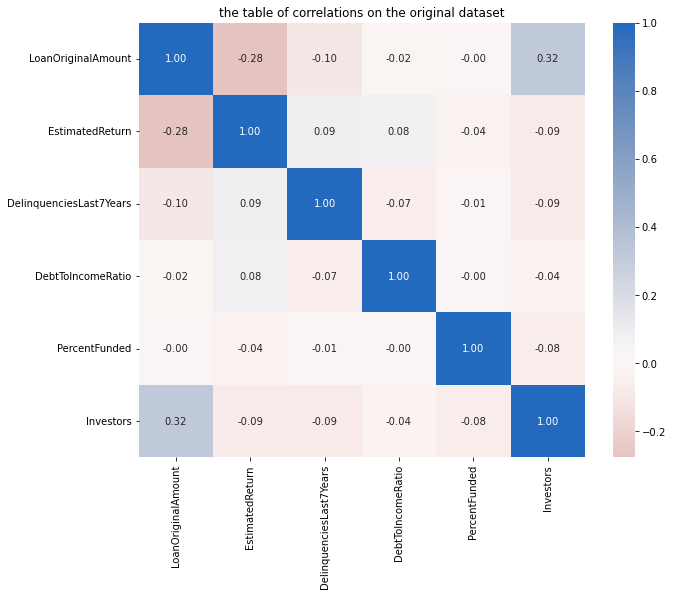

```python
plt.figure(figsize = [10, 8])
plt.title('the table of correlations on the original dataset')
sb.heatmap(loan[num].corr(), annot = True, fmt = '.2f',
           cmap = 'vlag_r', center = 0)
plt.show()
```

like we see there is no strong correlation between variable, what we can do is to see for the sample dataset created above

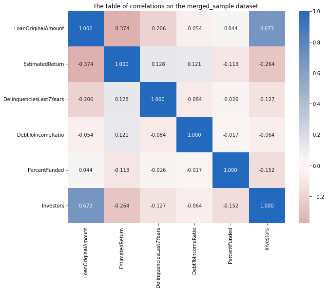

```python
plt.figure(figsize = [10, 8])
plt.title('the table of correlations on the merged_sample dataset')
sb.heatmap(merged_sample[num].corr(), annot = True, fmt = '.3f',
           cmap = 'vlag_r', center = 0)
plt.show()
```

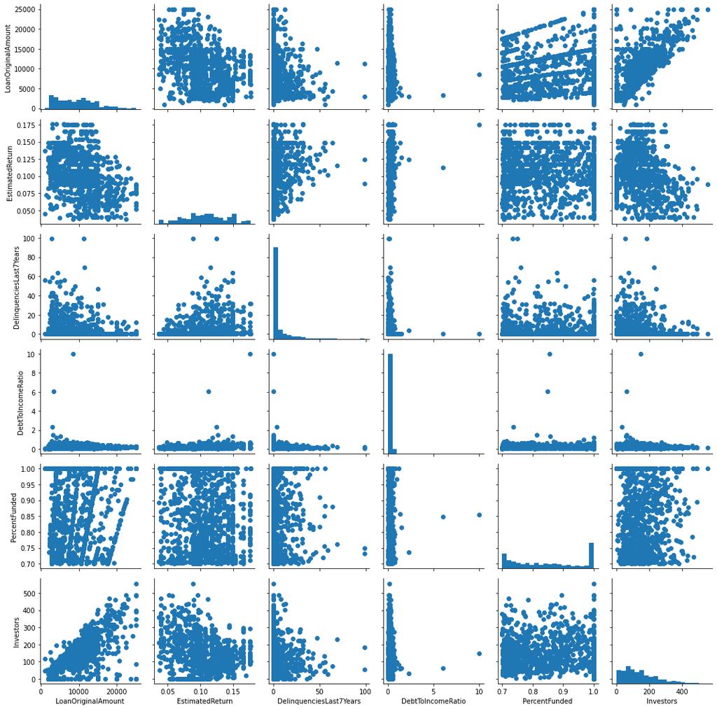

```python
g = sb.PairGrid(data = merged_sample, vars = num)
g = g.map_diag(plt.hist, bins = 20);
g.map_offdiag(plt.scatter)
```

We took the merged_sample data set and we did the same visualization, we found that the only strong correlation is between the loanOriginalAmount and the number of investors. we will see how the correlation is between percentFunding, investors and the categorical variables

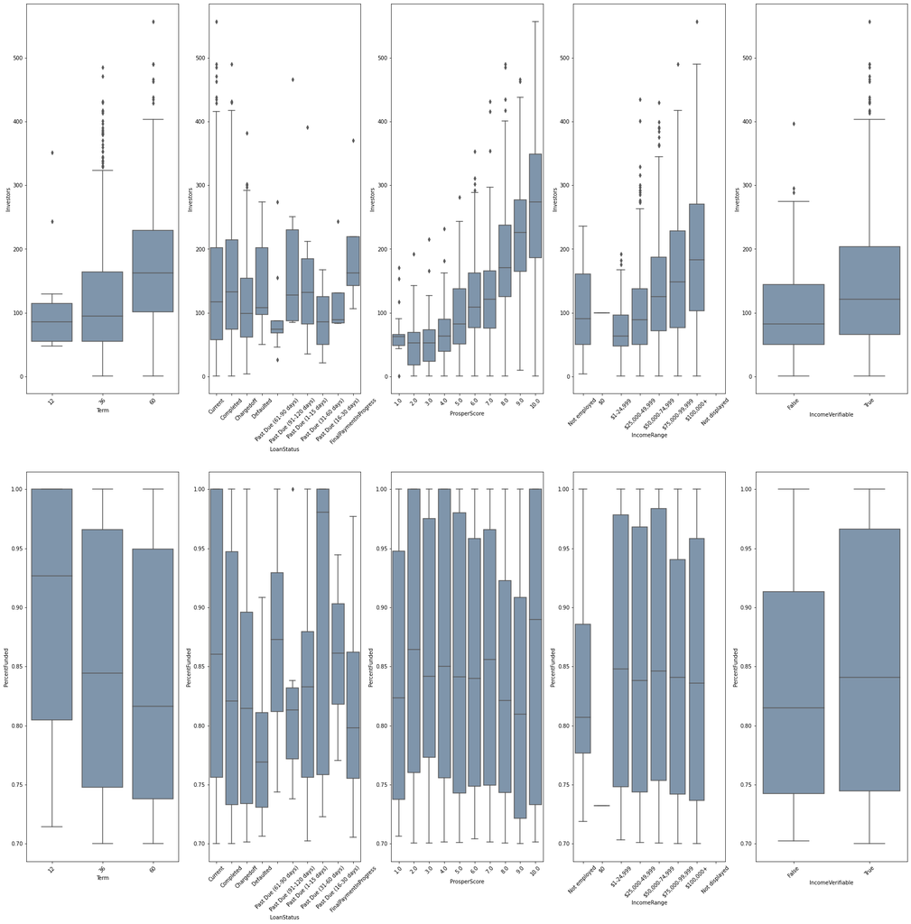

```python
plt.figure(figsize = [30, 30])
for x in range(1,6):
    plt.subplot(2,5,x)
    sb.boxplot(data=merged_sample, x=cat[x-1], y='Investors', color=colorM)
    plt.xticks(rotation=45)
for x in range(1,6):
    plt.subplot(2,5,x+5)
    sb.boxplot(data=merged_sample, x=cat[x-1], y='PercentFunded', color=colorM)
    plt.xticks(rotation=45)

plt.show()
```

we are gonna perform the same operation on a sample from the original dataset

```python
loan_samp=loan.sample(2000)
```

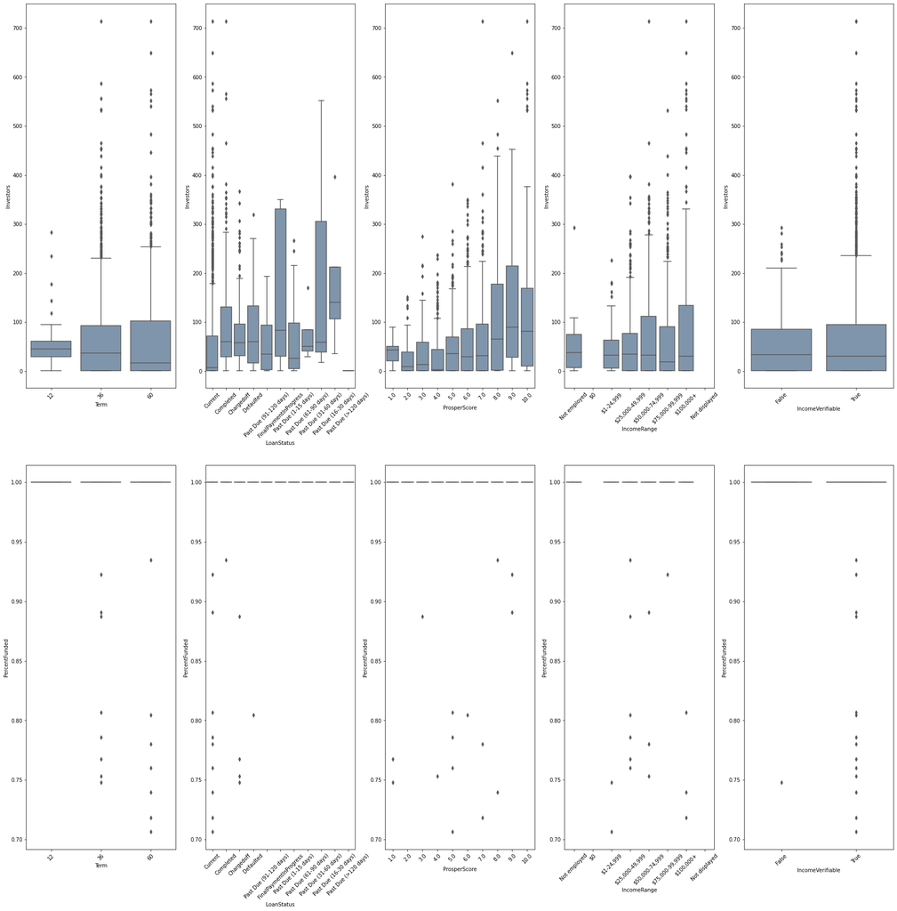

```python
plt.figure(figsize = [30, 30])
for x in range(1,6):
    plt.subplot(2,5,x)
    sb.boxplot(data=loan_samp, x=cat[x-1], y='Investors', color=colorM)
    plt.xticks(rotation=45)
for x in range(1,6):
    plt.subplot(2,5,x+5)
    sb.boxplot(data=loan_samp, x=cat[x-1], y='PercentFunded', color=colorM)
    plt.xticks(rotation=45)

plt.show()
```

## 2. On this part we will the relation between the estimated return, LoanOriginalAmount, DelinquenciesLast7Years and DebtToIncomeRatio with the number of investors

```python
def scatter(data,x,y,til):
  plt.figure(figsize = [10, 8])
  plt.scatter(data =data , x = x, y = y, alpha=2/20)
  plt.xlabel(x)
  plt.ylabel(y)
  plt.title(til)
  plt.show()

def scatterlx(data,x,y,til):
  plt.figure(figsize = [10, 8])
  plt.scatter(data =data , x = x, y = y, alpha=2/20)
  plt.xscale('log')
  plt.xlabel(x)
  plt.ylabel(y)
  plt.title(til)
  plt.show()

def scatterly(data,x,y,til):
  plt.figure(figsize = [10, 8])
  plt.scatter(data =data , x = x, y = y, alpha=2/20)
  plt.xlabel(x)
  plt.ylabel(y)
  plt.yscale('log')
  plt.title(til)
  plt.show()
```

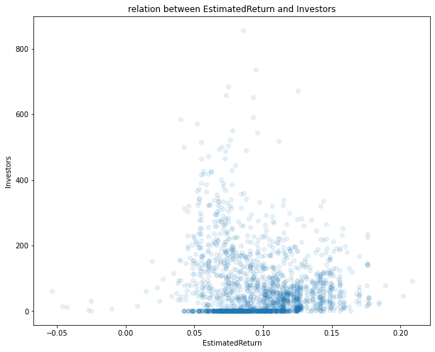

```python
scatter(data =loan_samp , x = 'EstimatedReturn', y = 'Investors',til='relation between EstimatedReturn and Investors')
```

We can see that when the estimated return increase the number of investors become concentrated and decrease, we can makes some assumptions that investors are willing to invest more on a loan that make no place for others, the line on 1 investor become more and more thick as the increase of the estimated return but stops after 13%.

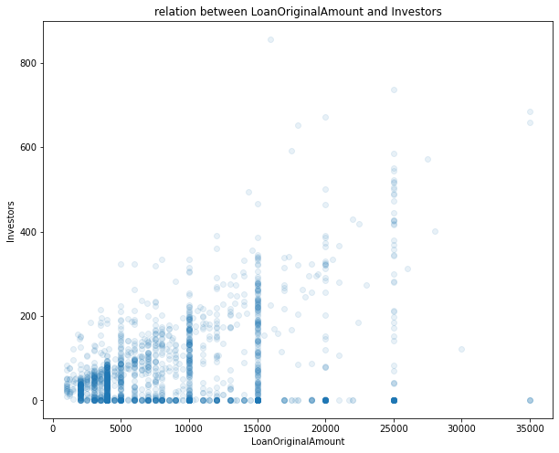

```python
scatter(data =loan_samp , x = 'LoanOriginalAmount', y = 'Investors',til='relation between LoanOriginalAmount and Investors')
```

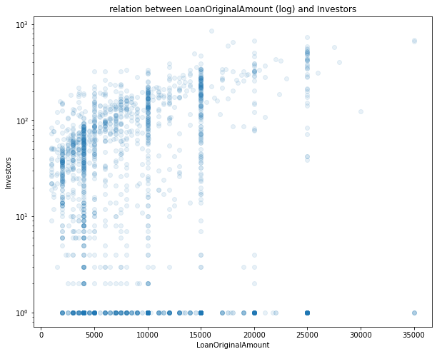

```python
scatterly(data =loan_samp , x = 'LoanOriginalAmount', y = 'Investors',til='relation between LoanOriginalAmount (log) and Investors')
```

We can see that a positive correlation between the two variables, we have a concentration on the low amounts, and reason is that a lot of loans have a low original amount as observed on the distribution of LoanOriginalAmount

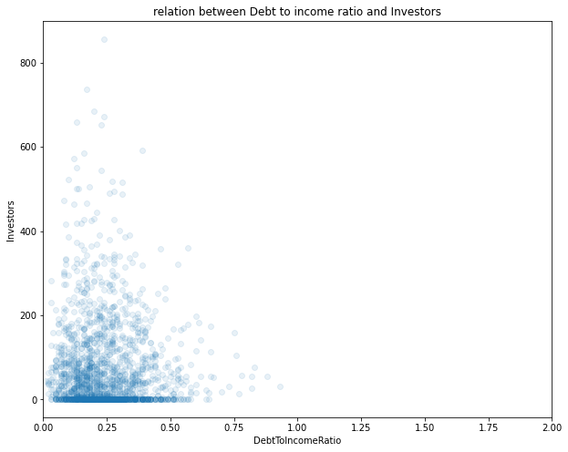

```python
plt.figure(figsize = [10, 8])
plt.scatter(data =loan_samp , x = 'DebtToIncomeRatio', y = 'Investors', alpha=2/20)
plt.xlabel('DebtToIncomeRatio')
plt.ylabel('Investors')
plt.xlim((0,2))
plt.title('relation between Debt to income ratio and Investors')
plt.show()
```

We can see there is a slight decrease of the number and the frequency of investors with the increase of the ratio

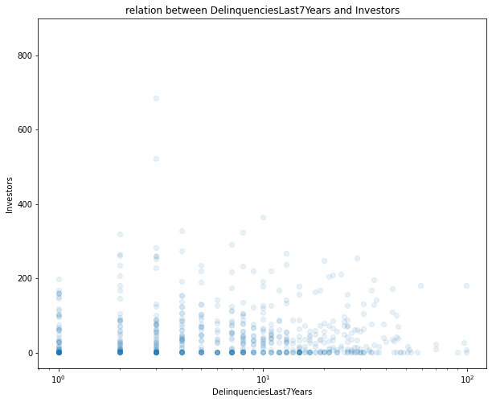

```python
scatterlx(data =loan_samp , x = 'DelinquenciesLast7Years', y = 'Investors',til='relation between DelinquenciesLast7Years and Investors')
```

We can see slight decrease of the number of investors with an increase on the number on delinquencies

## 3. We will study the relation between the estimated return, LoanOriginalAmount and DebtToIncomeRatio with the PercentFunded

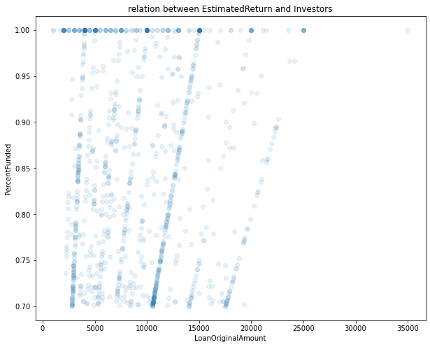

```python
scatter(data =merged_sample , x = 'LoanOriginalAmount', y = 'PercentFunded',til='relation between EstimatedReturn and Investors')
```

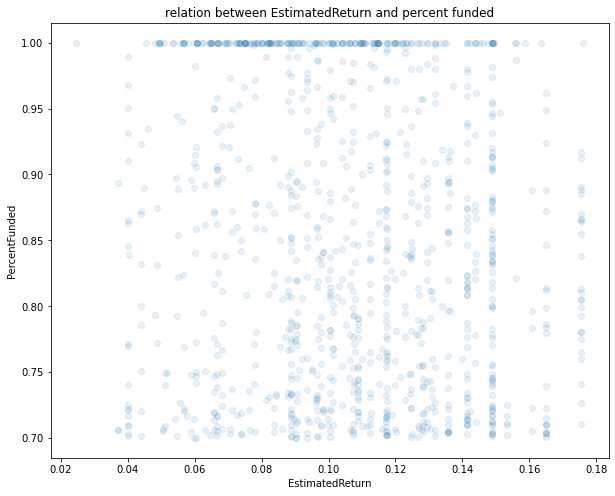

```python
scatter(data =merged_sample , x = 'EstimatedReturn', y = 'PercentFunded',til='relation between EstimatedReturn and percent funded')
```

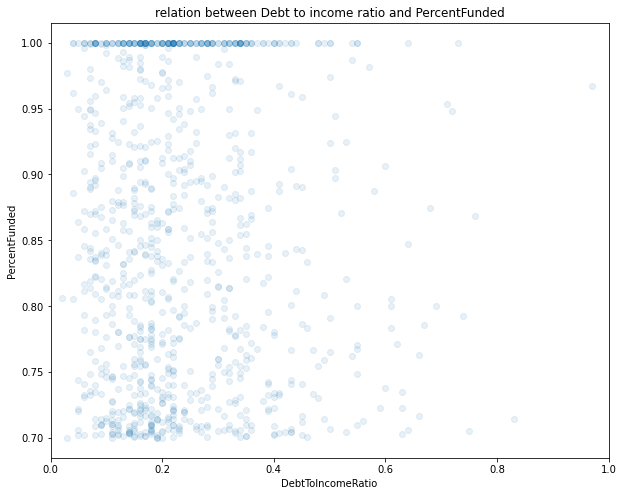

```python
plt.figure(figsize = [10, 8])
plt.scatter(data =merged_sample , x = 'DebtToIncomeRatio', y = 'PercentFunded', alpha=2/20)
plt.xlabel('DebtToIncomeRatio')
plt.ylabel('PercentFunded')
plt.xlim((0,1))
plt.title('relation between Debt to income ratio and PercentFunded')
plt.show()
```

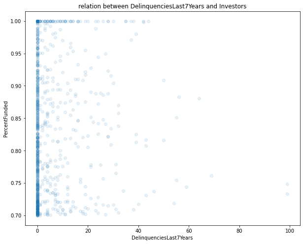

```python
scatter(data =merged_sample , x = 'DelinquenciesLast7Years', y = 'PercentFunded',til='relation between DelinquenciesLast7Years and Investors')
```

We cannot see any relation between the two variables

### Did you observe any interesting relation between the other features (not the main feature(s) of interest)?

> Unfortunately this dataset show no interesting relation between other variables